# Topic 6-01: Visualization

Zuguang Gu z.gu@dkfz.de

2025-03-02

## ORA result

### Single ORA result

```r
library(GSEAtraining)

lt = readRDS(system.file("extdata", "ora.rds", package = "GSEAtraining"))
diff_gene = lt$diff_gene
diff_gene = convert_to_entrez_id(diff_gene)
```

```
##   gene id might be SYMBOL (p =  0.990 )
```

```r
library(clusterProfiler)
library(org.Hs.eg.db)
res = enrichGO(gene = diff_gene, ont = "BP", OrgDb = org.Hs.eg.db, pvalueCutoff = 1)
res = add_more_columns(res)
```

Let’s start with the enrichment table from the ORA analysis.

```r
tb = res@result
head(tb)
```

```
##                    ID                                  Description GeneRatio
## GO:0002274 GO:0002274                 myeloid leukocyte activation    51/779
## GO:0002237 GO:0002237     response to molecule of bacterial origin    63/779
## GO:0032496 GO:0032496               response to lipopolysaccharide    61/779
## GO:0050729 GO:0050729 positive regulation of inflammatory response    40/779
## GO:0050727 GO:0050727          regulation of inflammatory response    66/779
## GO:0002697 GO:0002697        regulation of immune effector process    63/779
##              BgRatio RichFactor FoldEnrichment   zScore       pvalue
## GO:0002274 247/18986  0.2064777       5.032331 13.19430 5.149704e-22
## GO:0002237 375/18986  0.1680000       4.094542 12.51936 6.945328e-22
## GO:0032496 354/18986  0.1723164       4.199742 12.57018 8.355530e-22
## GO:0050729 162/18986  0.2469136       6.017845 13.26703 1.676133e-20
## GO:0050727 438/18986  0.1506849       3.672534 11.70487 3.037134e-20
## GO:0002697 410/18986  0.1536585       3.745008 11.62289 8.217123e-20
##                p.adjust       qvalue
## GO:0002274 1.409021e-18 1.099119e-18
## GO:0002237 1.409021e-18 1.099119e-18
## GO:0032496 1.409021e-18 1.099119e-18
## GO:0050729 2.119890e-17 1.653638e-17
## GO:0050727 3.072972e-17 2.397098e-17
## GO:0002697 6.928404e-17 5.404561e-17
##                                                                                                                                                                                                                                                                                                          …
## GO:0002274                                                                                       2268/7305/6556/22904/8692/3430/54209/50487/3696/3458/7474/91…
## GO:0002237                                   4843/6401/6556/50943/22904/5743/2920/3595/54209/3055/54/7302…
## GO:0032496                                            4843/6401/6556/50943/22904/5743/2920/3595/54209/3055/54/7302…
## GO:0050729                                                                                                                                               8692/3430/5743/58484/54209/5008/50487/4210/5054/59341/3458/7…
## GO:0050727 2268/6401/3082/50943/22904/8692/3430/55737/5743/58484/54209/…
## GO:0002697                       2268/4843/7305/50943/7037/2219/3383/54209/50487/54/3458/942/…
##            Count n_hits n_genes gs_size n_totle log2_fold_enrichment  z_score
## GO:0002274    51     51     779     247   18986             2.331227 13.19430
## GO:0002237    63     63     779     375   18986             2.033702 12.51936
## GO:0032496    61     61     779     354   18986             2.070301 12.57018
## GO:0050729    40     40     779     162   18986             2.589247 13.26703
## GO:0050727    66     66     779     438   18986             1.876776 11.70487
## GO:0002697    63     63     779     410   18986             1.904969 11.62289
```

The mostly-used type of plot is to use simple statistical graphics for a small set of pre-selected gene sets.

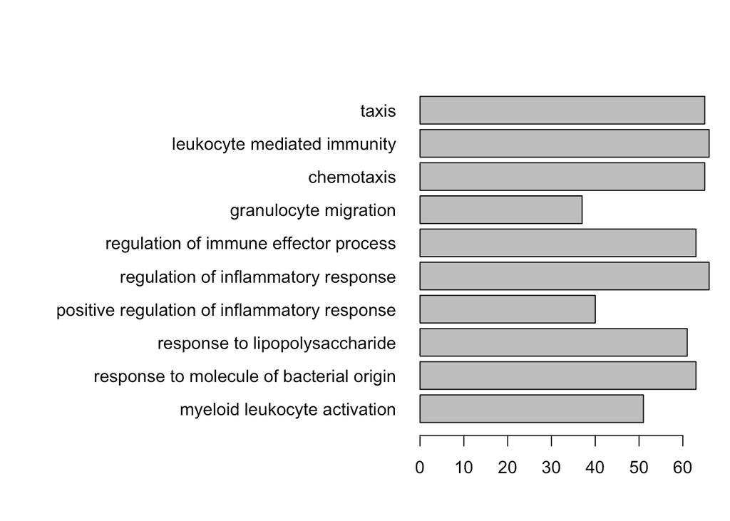

```r
par(mar = c(4.1, 20, 4, 1))
barplot(tb$n_hits[1:10], horiz = TRUE, names.arg = tb$Description[1:10], las = 1)
```

Using **ggplot2** is a better idea for visualizing data.

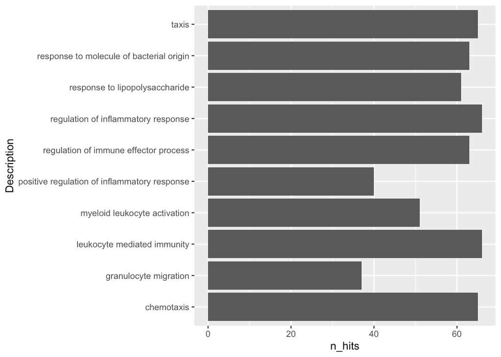

```r
library(ggplot2)
ggplot(tb[1:10, ], aes(x = n_hits, y = Description)) +
    geom_col()
```

Number of DE genes in gene set may not be a good statistic, more commonly used statistics are log2 fold enrichment or -log10 p.adjust.

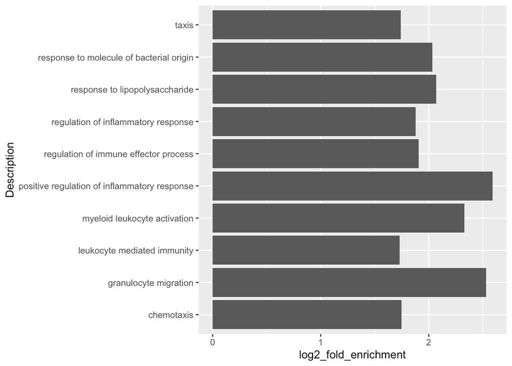

```r
ggplot(tb[1:10, ], aes(x = log2_fold_enrichment, y = Description)) +
    geom_col()
```

It is also common to add the p-values/adjusted p-values to the bars.

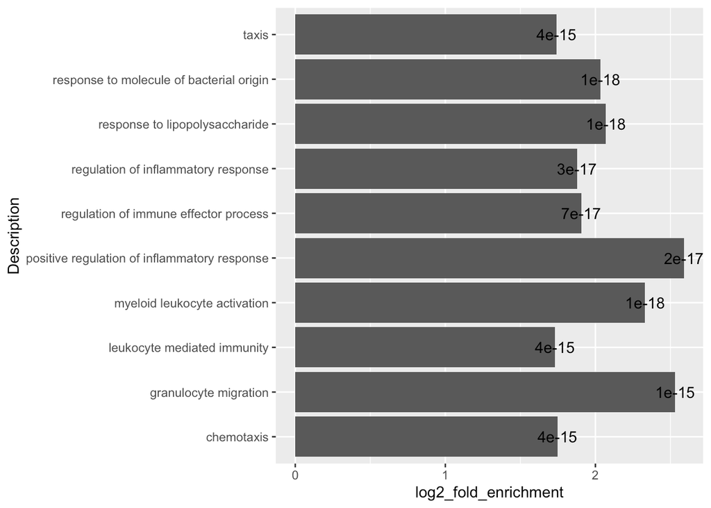

```r
ggplot(tb[1:10, ], aes(x = log2_fold_enrichment, y = Description)) +
    geom_col() +
    geom_text(aes(x = log2_fold_enrichment, label = sprintf('%1.e', p.adjust)))
```

By default, **ggplot2** reorders labels alphabetically. You can set the name as a factor and specify the order there.

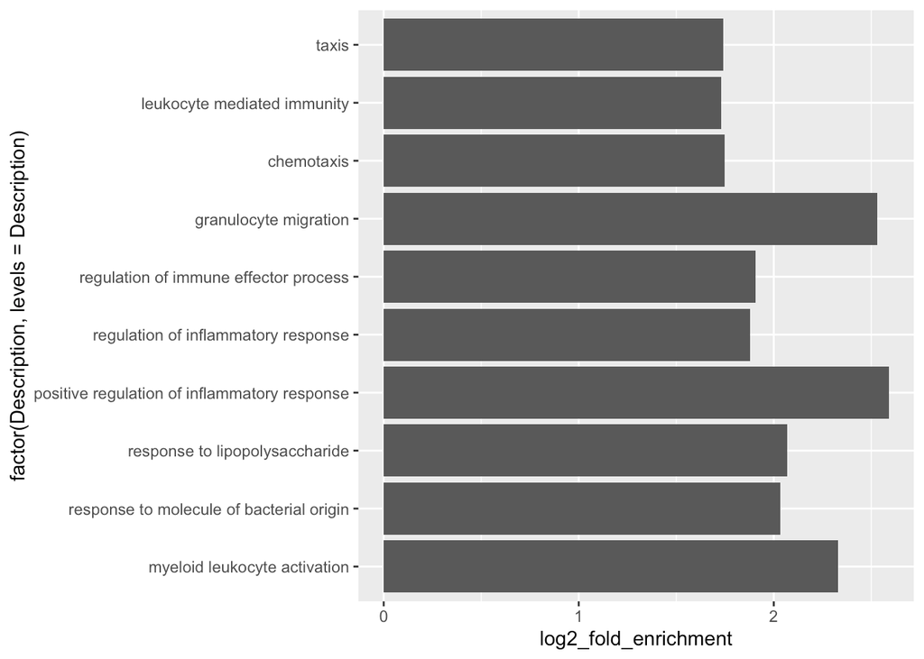

```r
ggplot(tb[1:10, ], aes(x = log2_fold_enrichment, y = factor(Description, levels = Description))) +
    geom_col()
```

Points are also very frequently used.

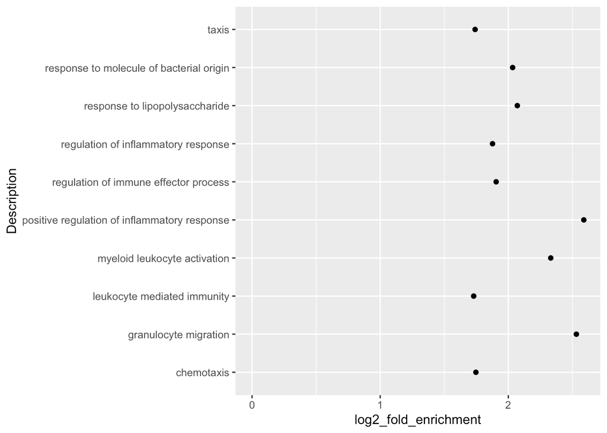

```r
ggplot(tb[1:10, ], aes(x = log2_fold_enrichment, y = Description)) +
    geom_point() +
    xlim(0, max(tb$log2_fold_enrichment[1:10]))
```

Using dot plot, we can map a second statistic to the size of dots.

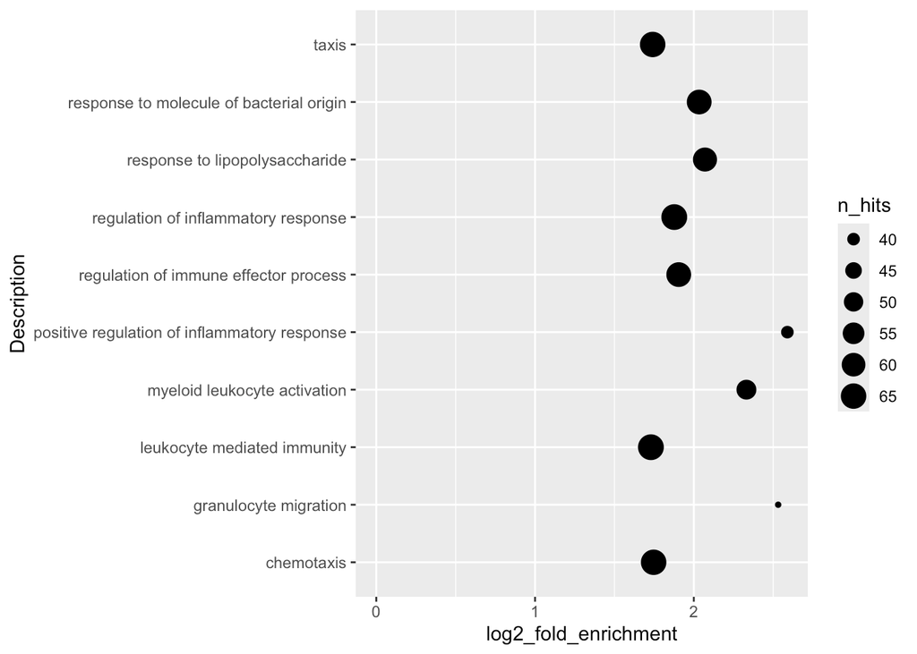

```r
ggplot(tb[1:10, ], aes(x = log2_fold_enrichment, y = Description, size = n_hits)) +
    geom_point() +
    xlim(0, max(tb$log2_fold_enrichment[1:10]))
```

Even more, we can map a third statistic to the dot colors.

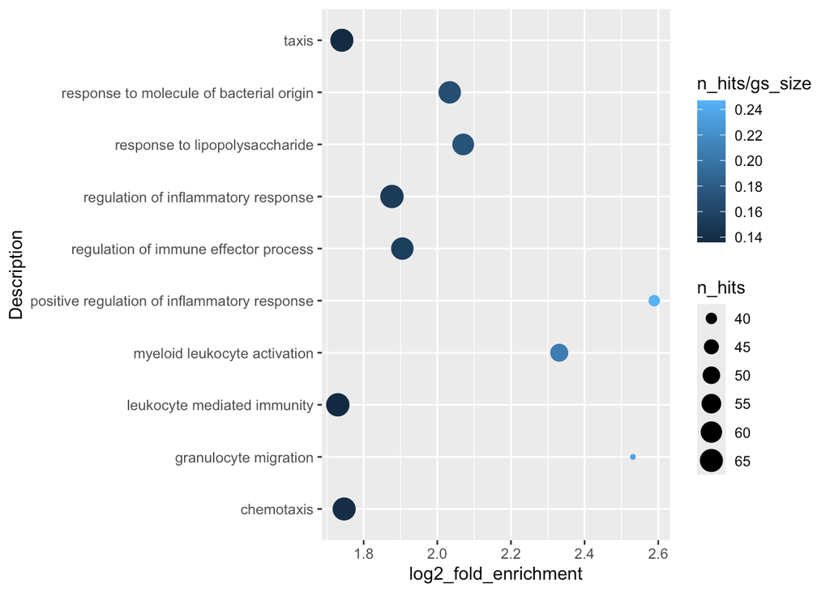

```r
ggplot(tb[1:10, ], aes(x = log2_fold_enrichment, y = Description, size = n_hits, col = n_hits/gs_size)) +
    geom_point()
```

A volcano plot which is -log10(p.adjust) vs log2 fold enrichment:

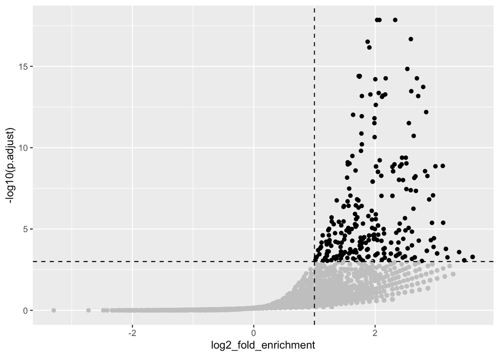

```r
ggplot(tb, aes(x = log2_fold_enrichment, y = -log10(p.adjust))) +
    geom_point(col = ifelse(tb$log2_fold_enrichment > 1 & tb$p.adjust < 0.001, "black", "grey")) +
    geom_hline(yintercept = 3, lty = 2) + geom_vline(xintercept = 1, lty = 2)
```

With the volcano plot, we can easily see the preference of enrichment to the sizes of gene sets.

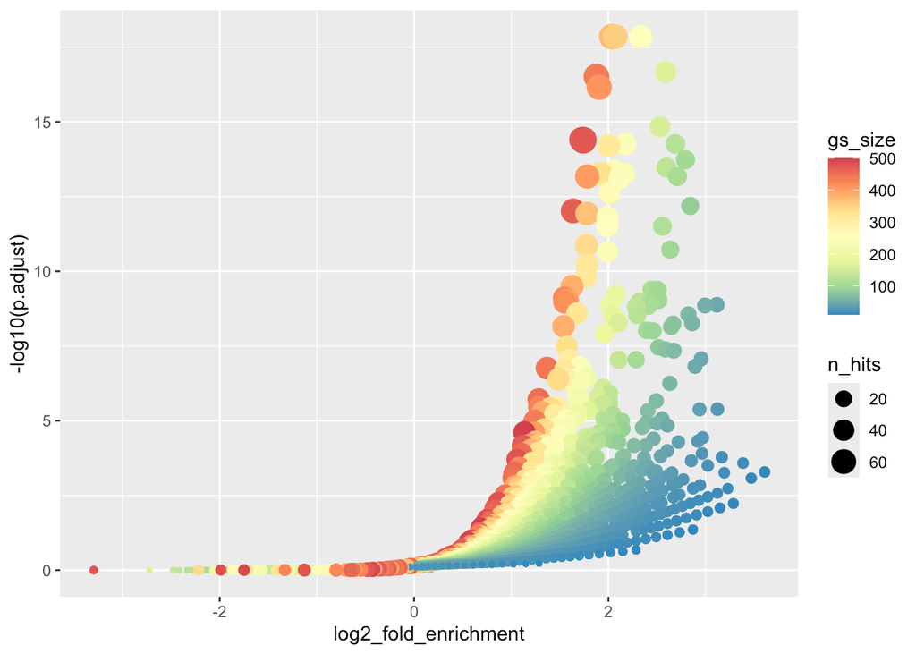

```r
ggplot(tb, aes(x = log2_fold_enrichment, y = -log10(p.adjust), color = gs_size, size = n_hits)) +
    geom_point() + scale_colour_distiller(palette = "Spectral")
```

### Visualizations from clusterProfiler

**clusterProfiler** provides many visualization functions (now these functions are all moved into a new **enrichplot** package).

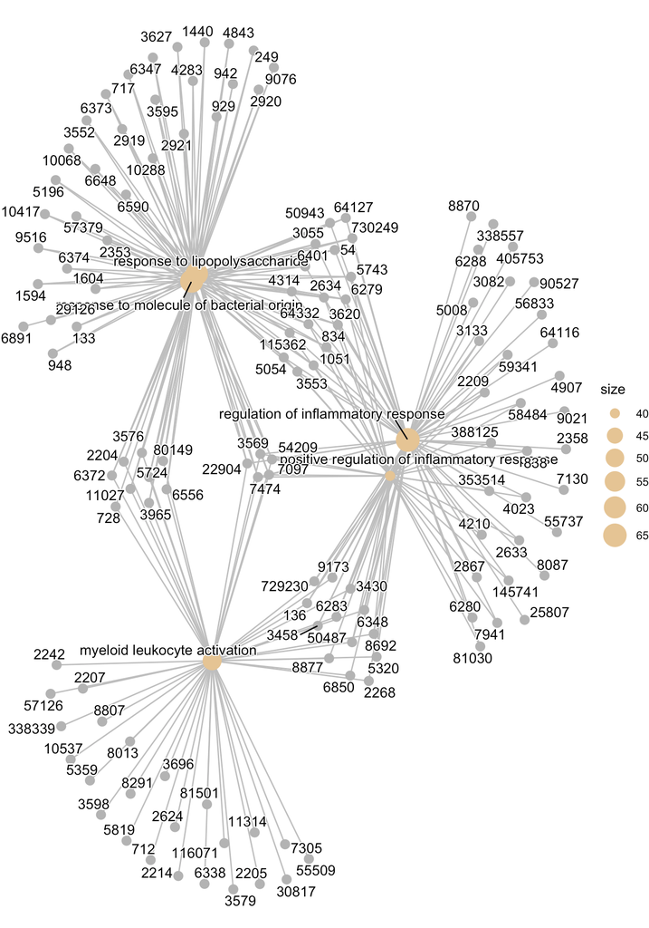

```r
library(enrichplot)
cnetplot(res)
```

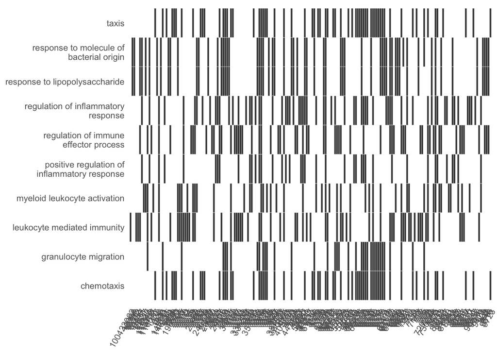

```r
heatplot(res, showCategory = 10)
```

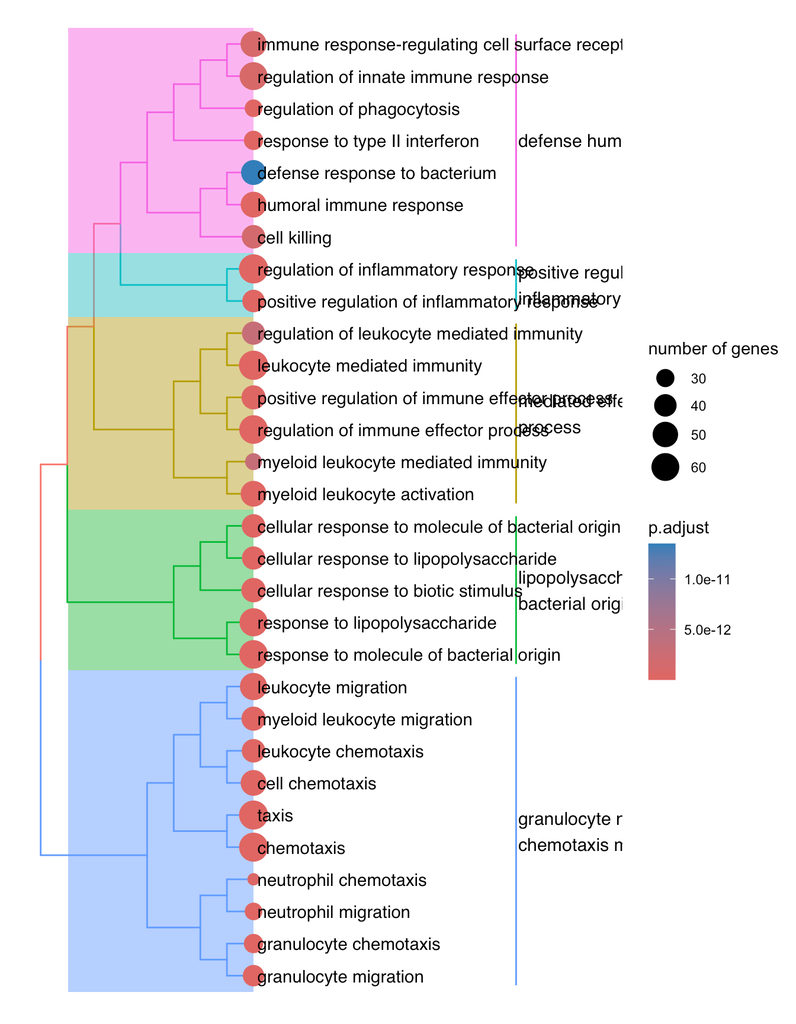

```r
res = pairwise_termsim(res)
treeplot(res)
```

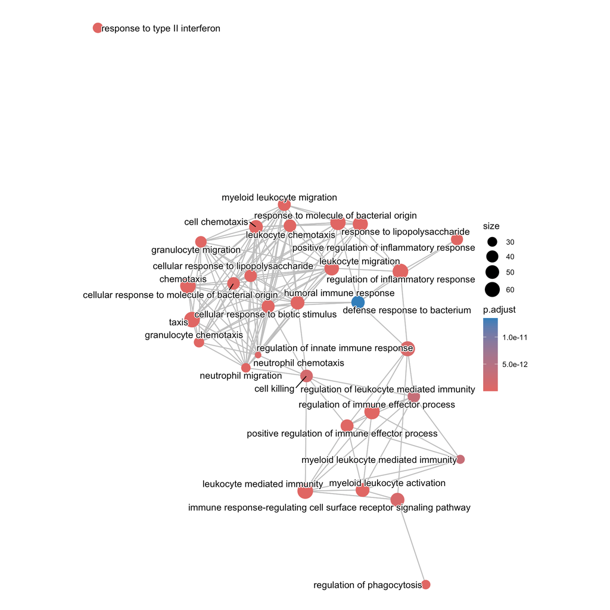

```r
emapplot(res)
```

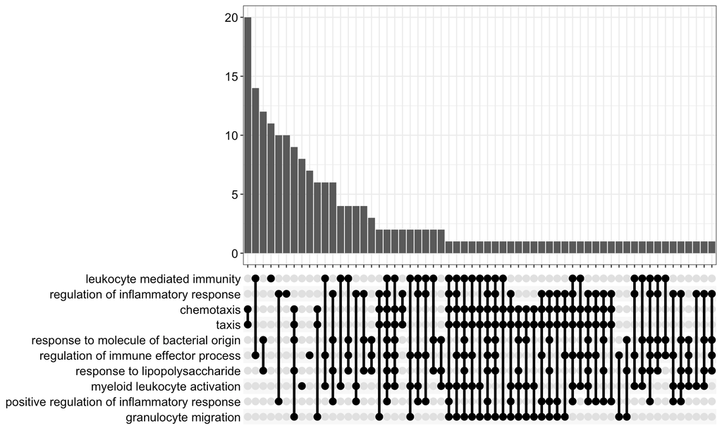

```r
upsetplot(res)
```

### Multiple ORA results

To visualize multiple ORA enrichment tables in one plot, we need to first prepare a data frame which combines results for a pre-selected gene sets.

```r
lt = readRDS(system.file("extdata", "lt_enrichment_tables.rds", package = "GSEAtraining"))

set.seed(666)
terms = sample(lt[[1]]$ID, 10)

tb = NULL
for(nm in names(lt)) {
    x = lt[[nm]]
    x = x[x$ID %in% terms, colnames(x) != "geneID"]
    x$sample = nm
    tb = rbind(tb, x)
}
```

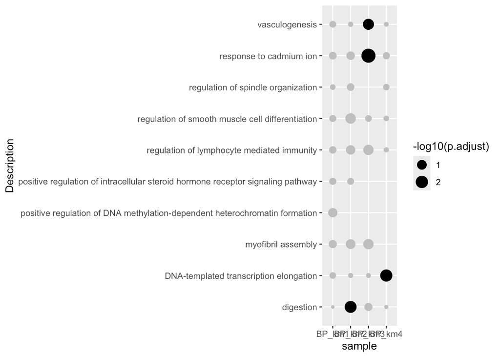

```r
ggplot(tb, aes(x = sample, y = Description, size = -log10(p.adjust))) +
    geom_point(color = ifelse(tb$p.adjust < 0.05, "black", "grey"))
```

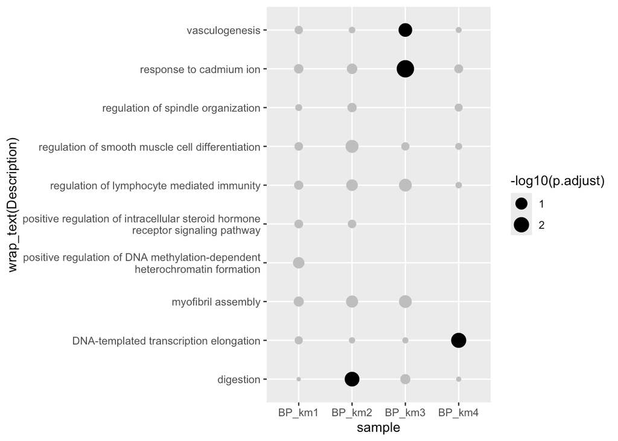

```r
ggplot(tb, aes(x = sample, y = wrap_text(Description), size = -log10(p.adjust))) +
    geom_point(color = ifelse(tb$p.adjust < 0.05, "black", "grey"))
```

## GSEA result

### Single GSEA result

```r
gene_diff_score = readRDS(system.file("extdata", "gene_diff_score.rds", package = "GSEAtraining"))
gene_diff_score = convert_to_entrez_id(gene_diff_score)
```

```
##   gene id might be SYMBOL (p =  1.000 )
```

```r
gene_diff_score = sort(gene_diff_score, decreasing = TRUE)
res_gsea = gseGO(geneList = gene_diff_score, ont = "BP", OrgDb = org.Hs.eg.db, pvalueCutoff = 1)
```

```
## using 'fgsea' for GSEA analysis, please cite Korotkevich et al (2019).
```

```
## preparing geneSet collections...
```

```
## GSEA analysis...
```

```
## leading edge analysis...
```

```
## done...
```

```r
tb = res_gsea@result
head(tb)
```

```
##                    ID
## GO:0036503 GO:0036503
## GO:1902850 GO:1902850
## GO:0051225 GO:0051225
## GO:0031640 GO:0031640
## GO:0141061 GO:0141061
## GO:0007189 GO:0007189
##                                                                          Description
## GO:0036503                                                              ERAD pathway
## GO:1902850                 microtubule cytoskeleton organization involved in mitosis
## GO:0051225                                                          spindle assembly
## GO:0031640                                      killing of cells of another organism
## GO:0141061                                    disruption of cell in another organism
## GO:0007189 adenylate cyclase-activating G protein-coupled receptor signaling pathway
##            setSize enrichmentScore       NES       pvalue   p.adjust     qvalue
## GO:0036503      38      -0.5403979 -2.169094 2.892345e-05 0.01735772 0.01570349
## GO:1902850      71      -0.4575756 -2.124133 9.177007e-06 0.01735772 0.01570349
## GO:0051225      48      -0.4909731 -2.062469 3.701280e-05 0.01735772 0.01570349
## GO:0031640      80       0.4685226  1.953506 5.703584e-05 0.01735772 0.01570349
## GO:0141061      80       0.4685226  1.953506 5.703584e-05 0.01735772 0.01570349
## GO:0007189     110       0.4173669  1.820810 6.263811e-05 0.01735772 0.01570349
##            rank                   leading_edge
## GO:0036503 1955 tags=58%, list=29%, signal=41%
## GO:1902850 1730 tags=51%, list=26%, signal=38%
## GO:0051225 1866 tags=58%, list=28%, signal=42%
## GO:0031640 1855 tags=50%, list=28%, signal=37%
## GO:0141061 1855 tags=50%, list=28%, signal=37%
## GO:0007189 1740 tags=46%, list=26%, signal=35%
##                                                                                                                                                                                                                                                     core_enrichment
## GO:0036503                                                                                                                                         7327/10134/22926/9709/6400/7415/4287/9354/811/6048/857/3309/51439/5706/7466/3300/267/4121/51465/29978/9097/10277
## GO:1902850                                                                 991/5347/2316/7415/3303/4926/3925/23636/4134/1058/22974/2801/7283/9493/3833/8480/387/22919/332/55968/4085/9525/10252/8841/23291/8766/3837/891/10253/3611/7272/9183/10735/4751/9371/29899
## GO:0051225                                                                                                     11200/26054/991/5347/2316/22924/3303/4926/140609/22974/2801/9493/3833/2959/10844/1642/387/22919/332/9525/8841/203068/8766/3837/10735/4751/9371/29899
## GO:0031640                                                   1668/6223/6357/1113/6366/4814/6372/729/6370/2919/383/10563/2920/10850/6362/3002/6375/735/5551/6356/3001/6364/4589/3458/3273/1511/6363/731/733/1610/5443/10578/57151/6387/3347/4283/1669/3827/4818/6156
## GO:0141061                                                   1668/6223/6357/1113/6366/4814/6372/729/6370/2919/383/10563/2920/10850/6362/3002/6375/735/5551/6356/3001/6364/4589/3458/3273/1511/6363/731/733/1610/5443/10578/57151/6387/3347/4283/1669/3827/4818/6156
## GO:0007189 150/23295/3362/1113/3360/7432/19/5573/8477/112/107/1812/4157…
```

Similarly, we can visualize NES scores of gene sets.

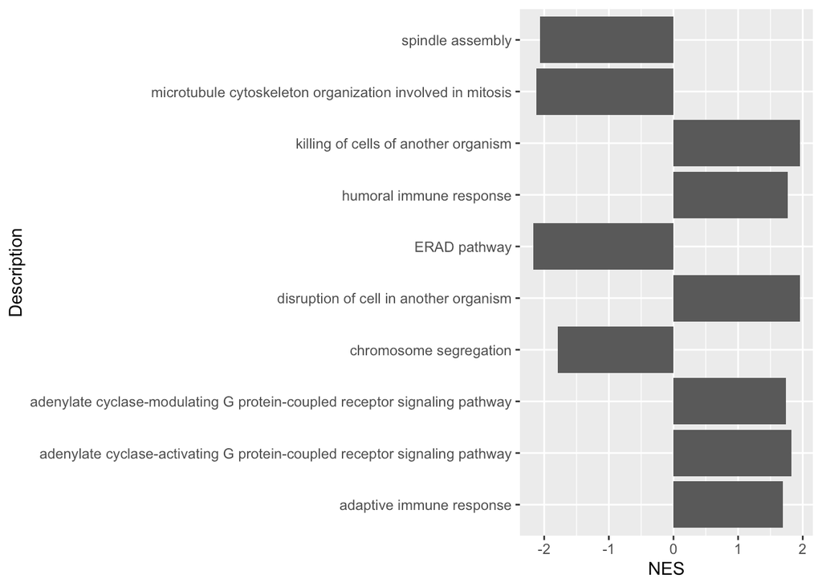

```r
ggplot(tb[1:10, ], aes(x = NES, y = Description)) +
    geom_col()
```

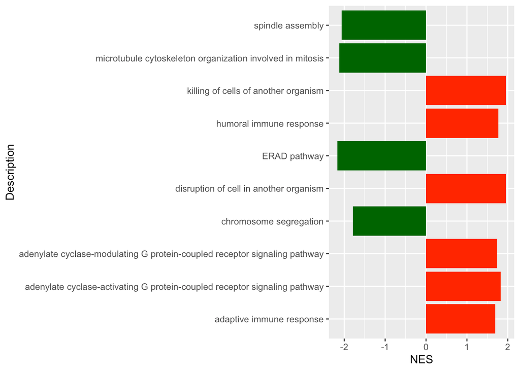

```r
ggplot(tb[1:10, ], aes(x = NES, y = Description)) +
    geom_col(fill = ifelse(tb$NES[1:10] > 0, "red", "darkgreen"))
```

The volcano plot:

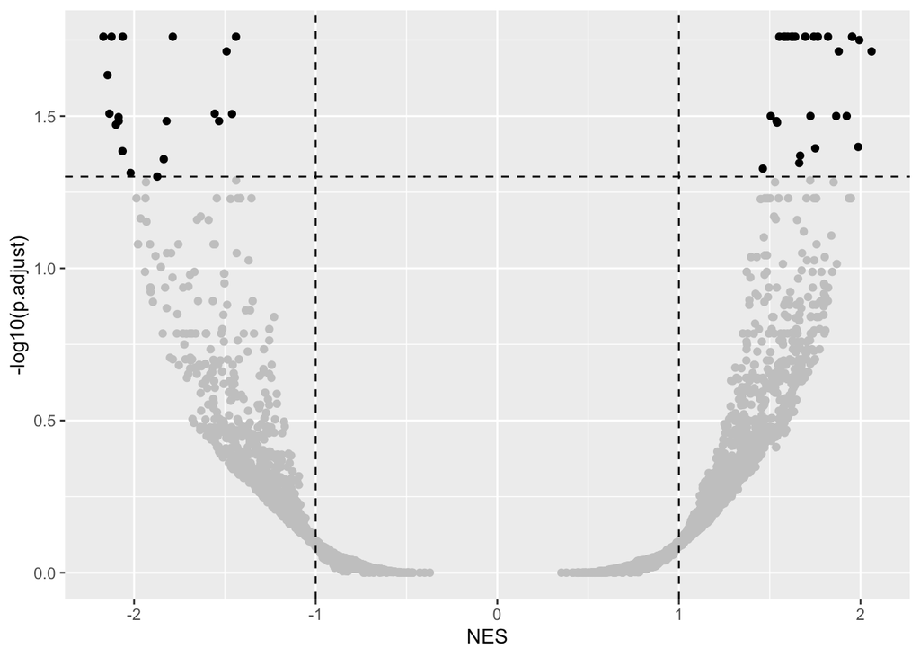

```r
ggplot(tb, aes(x = NES, y = -log10(p.adjust))) +
    geom_point(col = ifelse(abs(tb$NES) > 1 & tb$p.adjust < 0.05, "black", "grey")) +
    geom_hline(yintercept = -log10(0.05), lty = 2) + geom_vline(xintercept = c(1, -1), lty = 2)
```

The degree of enrichment is also dependent to the gene set sizes.

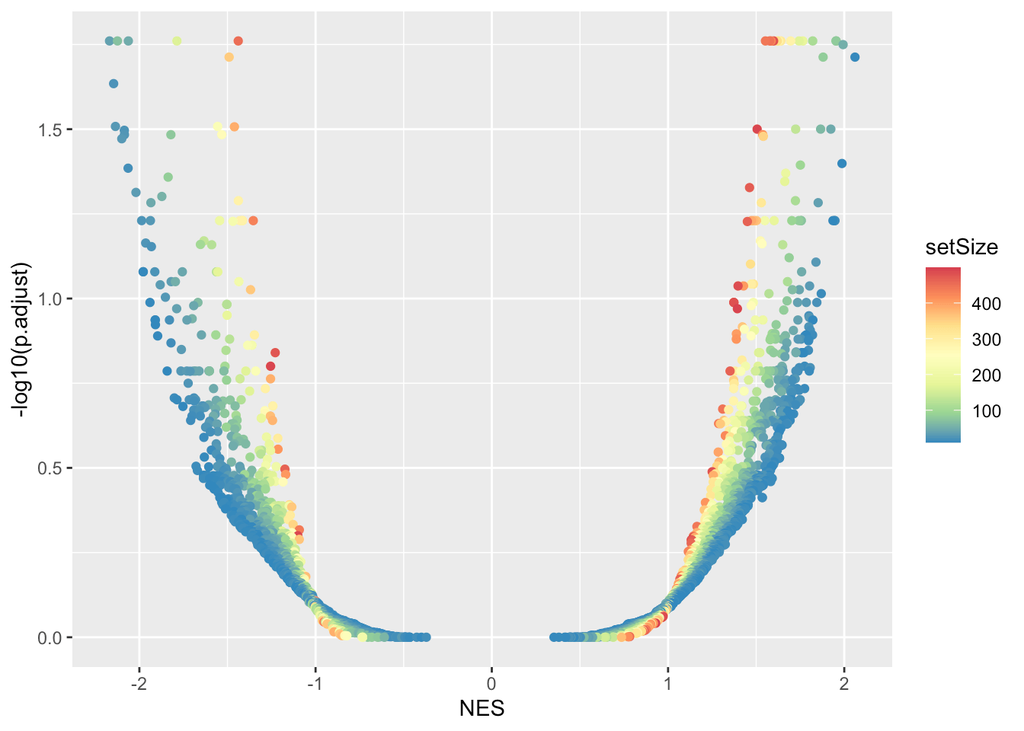

```r
ggplot(tb, aes(x = NES, y = -log10(p.adjust), color = setSize)) +
    geom_point() + scale_colour_distiller(palette = "Spectral")
```

The ridge plot (joy plot/mountain plot) visualizes the distribution of gene-level scores in each gene set.

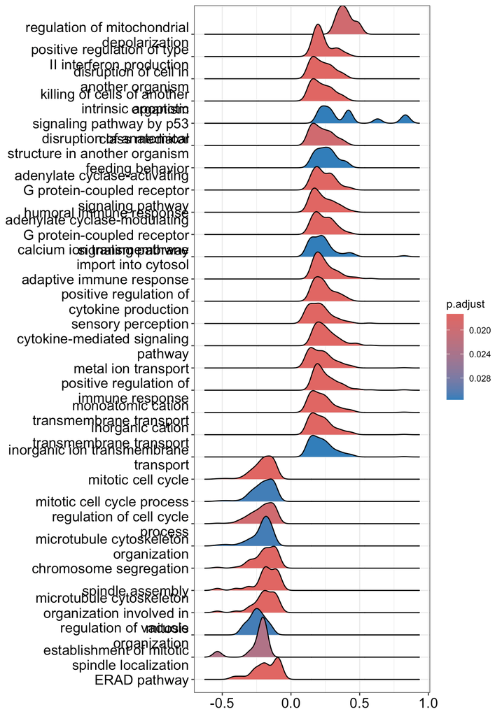

```r
ridgeplot(res_gsea)
```

And the classic GSEA plot:

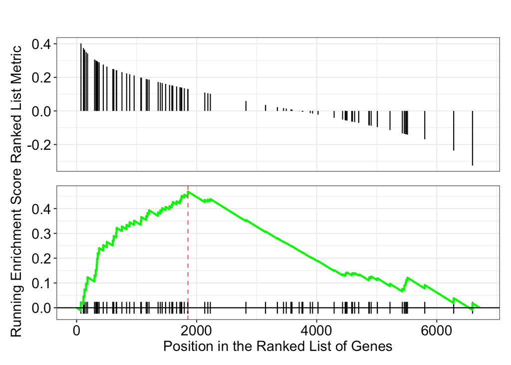

```r
gseaplot(res_gsea, geneSetID = 4)
```

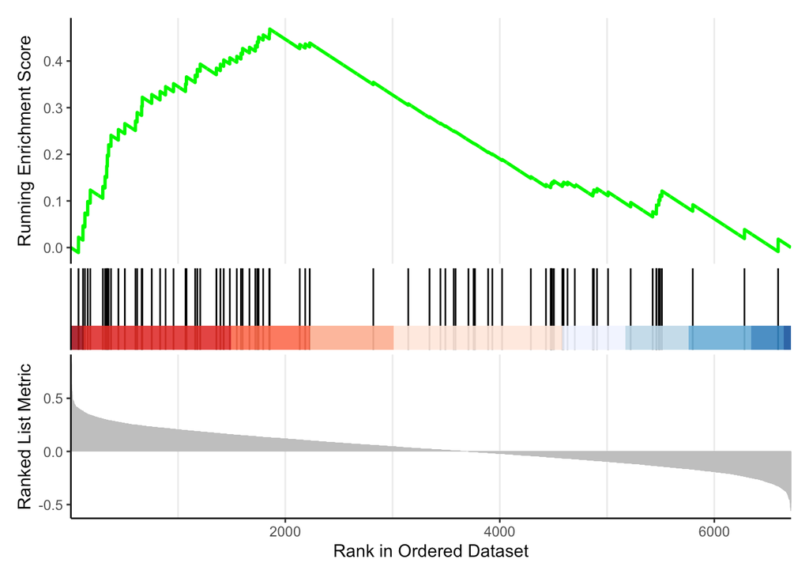

```r
gseaplot2(res_gsea, geneSetID = 4)
```

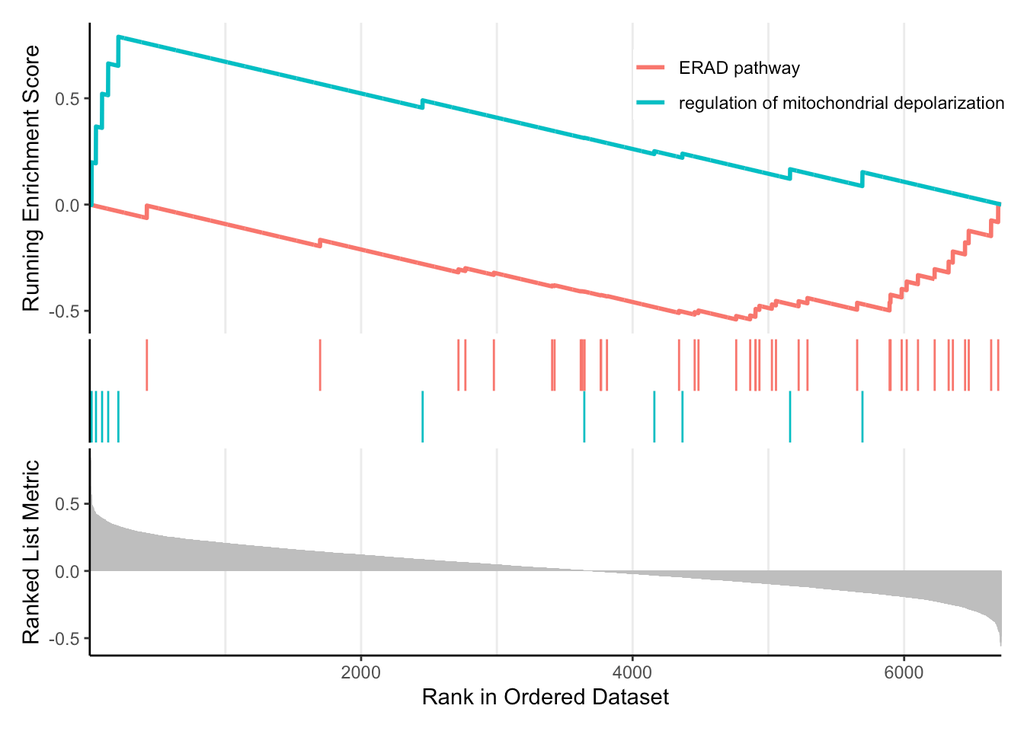

```r
ind = c(which.max(res_gsea@result$NES), which.min(res_gsea@result$NES))
gseaplot2(res_gsea, geneSetID = ind)
```